# DATS6101 Project 1

Mihir Gadgil, Elie Tetteh-Wayoe, Jessica Fogerty, Aluya Omofuma, Pierre Bamba

October 1, 2018

## Objectives

#### First we imported the data from: https://www.kaggle.com/heesoo37/120-years-of-olympic-history-athletes-and-results .

#### We noticed that each athlete was awarded a medal including each team member, we were able to subset the data so that each team was awarded a medal so that there was no discrepency.

#### Call the necessary packages for analysis. We used: ggplot2, dplyr.

#### Examine Structure of the data frame and then examined the five statistic summary.

#### Examine the formulated questions

#### Create visualizaions for analysis

## EDA

Loading the dataset and reviewing its structure

```
## 'data.frame':    271116 obs. of  15 variables:
##  $ ID    : int  1 2 3 4 5 5 5 5 5 5 ...
##  $ Name  : Factor w/ 134732 levels "  Gabrielle Marie \"Gabby\" Adcock (White-)",..: 8 9 44318 29412 21469 21469 21469 21469 21469 21469 ...
##  $ Sex   : Factor w/ 2 levels "F","M": 2 2 2 2 1 1 1 1 1 1 ...
##  $ Age   : int  24 23 24 34 21 21 25 25 27 27 ...
##  $ Height: int  180 170 NA NA 185 185 185 185 185 185 ...
##  $ Weight: num  80 60 NA NA 82 82 82 82 82 82 ...
##  $ Team  : Factor w/ 1184 levels "30. Februar",..: 199 199 273 278 705 705 705 705 705 705 ...
##  $ NOC   : Factor w/ 230 levels "AFG","AHO","ALB",..: 42 42 56 56 146 146 146 146 146 146 ...
##  $ Games : Factor w/ 51 levels "1896 Summer",..: 38 49 7 2 37 37 39 39 40 40 ...
##  $ Year  : int  1992 2012 1920 1900 1988 1988 1992 1992 1994 1994 ...
##  $ Season: Factor w/ 2 levels "Summer","Winter": 1 1 1 1 2 2 2 2 2 2 ...
##  $ City  : Factor w/ 42 levels "Albertville",..: 6 18 3 27 9 9 1 1 17 17 ...
##  $ Sport : Factor w/ 66 levels "Aeronautics",..: 9 33 25 62 54 54 54 54 54 54 ...
##  $ Event : Factor w/ 765 levels "Aeronautics Mixed Aeronautics",..: 160 398 349 710 623 619 623 619 623 619 ...
##  $ Medal : Factor w/ 3 levels "Bronze","Gold",..: NA NA NA 2 NA NA NA NA NA NA ...
```

We changed the structure of some of the columns such as medal, changed to ordered factor. We dropped Age, Height, Weight, City and Games. Select only the Summer Olympics data.

Insert host country data into the data frame. Change some country codes to simplify analysis.

```r
hosts <- data.frame(Year = c(seq(1896, 1912, 4), seq(1920, 1936, 4), seq(1948, 2016, 4)), Host_NOC = c("GRE", "FRA", "USA", "GBR", "SWE", "BEL", "FRA", "NED", "USA", "GER", "GBR", "FIN", "AUS", "ITA", "JPN", "MEX", "GER", "CAN", "RUS", "USA", "KOR", "ESP", "USA", "AUS", "GRE", "CHN", "GBR", "BRA"))
athletes <- merge(athletes, hosts, by.x = "Year", by.y = "Year")
athletes$Host_NOC[athletes$Year == 1956 & athletes$City == "Stockholm"] <- "SWE"
athletes$Host_NOC <- as.character(athletes$Host_NOC)
athletes$NOC[athletes$NOC == "URS"] <- "RUS"
athletes$NOC[athletes$NOC == "FRG"] <- "GER"
athletes$NOC[athletes$NOC == "GDR"] <- "GER"
athletes$NOC[athletes$NOC == "ANZ"] <- "AUS"
#Equating China and Hong Kong would help too, but it seems like they have been participating as different teams since 1952.
```

Interesting fact: 1906 had Olympic games, too. They were officially recognized as such at that time, but aren’t considered Olympic games now.

Five summary statistics of the dataset

```
##       Year            ID                                       Name
##  Min.   :1896   Min.   :     1   Robert Tait McKenzie            :    58
##  1st Qu.:1960   1st Qu.: 33988   Heikki Ilmari Savolainen        :    39
##  Median :1984   Median : 68266   Joseph "Josy" Stoffel           :    38
##  Mean   :1977   Mean   : 67978   Ioannis Theofilakis             :    33
##  3rd Qu.:2000   3rd Qu.:101862   Takashi Ono                     :    33
##  Max.   :2016   Max.   :135568   Alfrd (Arnold-) Hajs (Guttmann-):    32
##                                  (Other)                         :220586
##  Sex                   Team            NOC               Season
##  F: 59432   United States: 14445   Length:220819      Summer:220819
##  M:161387   Great Britain: 10205   Class :character   Winter:     0
##             France       :  9872   Mode  :character
##             Italy        :  8004
##             Germany      :  7221
##             Australia    :  6966
##             (Other)      :164106
##         Sport                                           Event
##  Athletics : 38154   Football Men's Football               :  5688
##  Gymnastics: 26551   Hockey Men's Hockey                   :  3958
##  Swimming  : 23117   Water Polo Men's Water Polo           :  3358
##  Shooting  : 11128   Basketball Men's Basketball           :  3280
##  Cycling   : 10721   Cycling Men's Road Race, Individual   :  2923
##  Fencing   : 10574   Gymnastics Men's Individual All-Around:  2475
##  (Other)   :100574   (Other)                               :199137
##     Medal          Host_NOC
##  Bronze: 11264   Length:220819
##  Silver: 11064   Class :character
##  Gold  : 11302   Mode  :character
##  NA's  :187189
##
##
##
```

This summary shows us that the United States, Great Britain, and France are the teams that participated the most frequently. The sports that had the highest number of participants were: Athletics, Gymnastics, Swimming. It is important to note that the three types of medals are not equal in numbers. This is because of ties.

## Analysis

### Does the Host Country have an advantage in Olympics?

First examine how many medals per country are won per olympic games

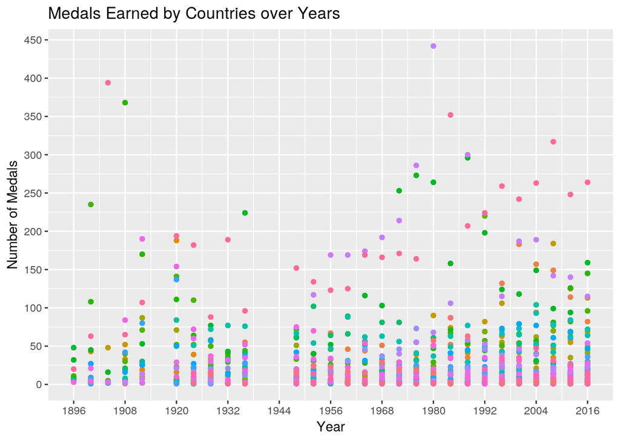

```r
#Find the total medal count per year
total_medals <- winners_only %>% group_by(Year) %>% summarize(Medal_Count = n())

#Include all of the host countries
hosts_only <- subset(winners_only, NOC %in% hosts$Host_NOC)

#Subset by medals won when the country that was a host country
medals_when_host <- subset(hosts_only, NOC == Host_NOC) %>% group_by(Year, NOC) %>% summarize(Medal_Count = n())
#Proportion of how many medals the host contry won out of all the medals avaliable for that year
host_medal_proportion <- data.frame(NOC = medals_when_host$NOC, Proportion = medals_when_host$Medal_Count / total_medals$Medal_Count)
#If a country hosted more than once, find the average of the proportion
host_medal_proportion <- host_medal_proportion %>% group_by(NOC) %>% summarize(Avg_Proportion = mean(Proportion))

#Subset by medals won when not acting as host country
medals_when_not_host <- subset(hosts_only, NOC != Host_NOC) %>% group_by(Year, NOC) %>% summarize(Medal_Count = n())
#Proportion of how many medals the host countries won out of medals avaliable when they are not host country
nonhost_medal_proportion <- merge(medals_when_not_host, total_medals, by.x = "Year", by.y = "Year")
nonhost_medal_proportion$Proportion <- nonhost_medal_proportion$Medal_Count.x / nonhost_medal_proportion$Medal_Count.y
#Average of proportion of medals won when a host country wasn't acting as a host country
nonhost_medal_proportion <- nonhost_medal_proportion %>% group_by(NOC) %>% summarize(Avg_Proportion = mean(Proportion))
```

Based on the visual inspection we would like to conduct a hypothesis test with the following hypothesis:  
$\mu_{D}$ is the difference between the average proportion of medals won as a host country and as a non host country  
$H_{0}: \mu_{D} = 0$  
$H_{1}: \mu_{D} > 0$  
Conduct a right tailed t-test to check whether a host country gets any advantage or not. Significance level $\alpha = 0.05$

```r
host_advantage_test <- t.test(host_medal_proportion$Avg_Proportion, nonhost_medal_proportion$Avg_Proportion, paired = T, conf.level = 0.95, alternative = "greater")
host_advantage_test
```

```
##
##  Paired t-test
##
## data:  host_medal_proportion$Avg_Proportion and nonhost_medal_proportion$Avg_Proportion
## t = 4.9669, df = 18, p-value = 4.987e-05
## alternative hypothesis: true difference in means is greater than 0
## 95 percent confidence interval:
##  0.05897526        Inf
## sample estimates:
## mean of the differences
##              0.09060909
```

The p-value $4.987133\times 10^{-5}$ is smaller than the significance level $0.05$.  
$\therefore$ We reject the null hypothesis.

# Participation of Men vs. Women

Take a look at the number of events conducted through years. Men/Women events counted separately.

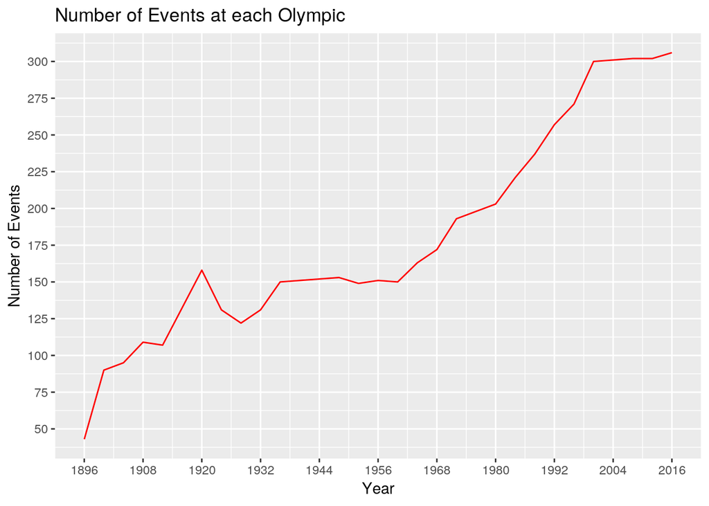

Athlete participation over years.

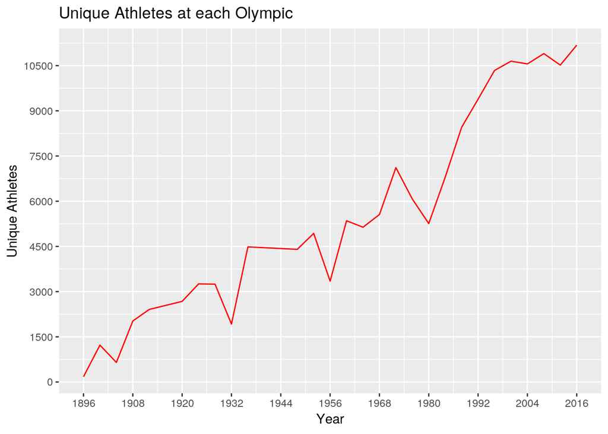

Men and Women Participation over the years.

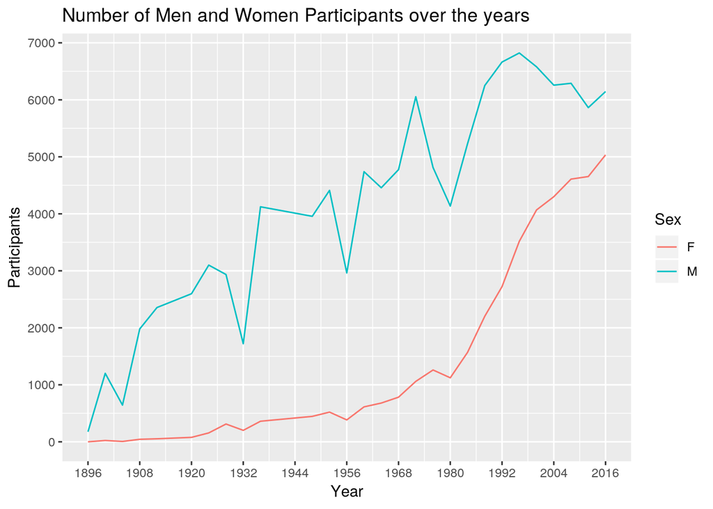

In fact the previous graph doesn’t do the situation justice. The proportion of women participating each year gives a better picture. As of 2016 45% of the total participants were women.

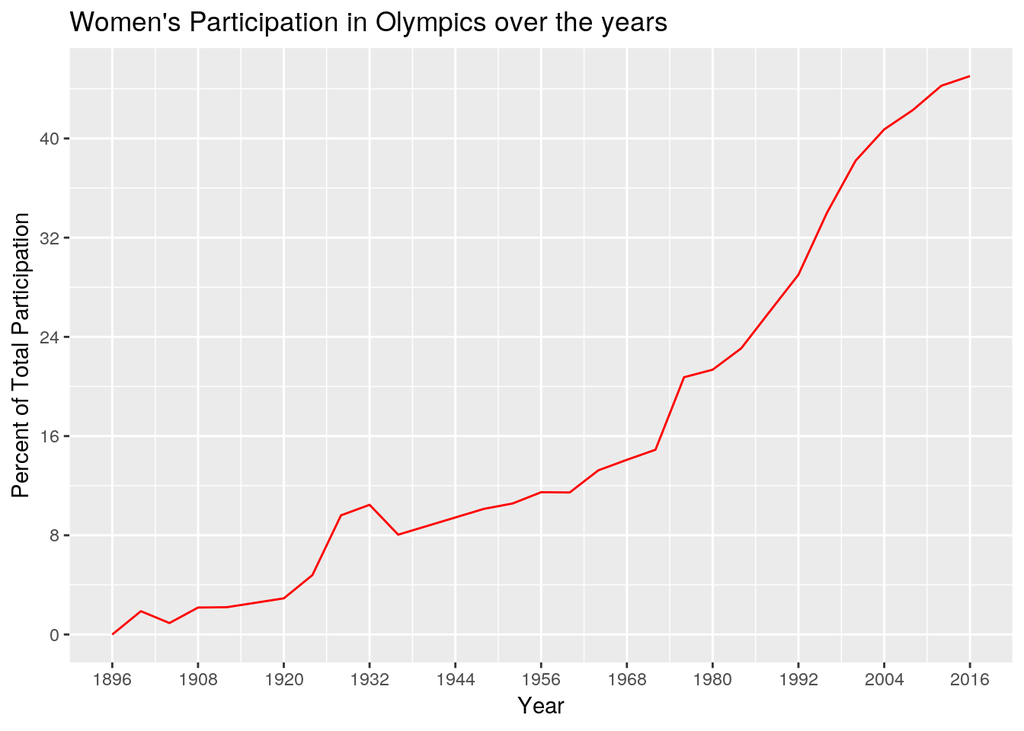

The linear model is:  
Proportion = Intercept + Slope $\times$ Year

```r
#Create linear model for difference in medal count VS year
proportion_model <- lm(I(Proportion - 0) ~ I(Year - 1896) + 0, data = women_participation)
slope <- proportion_model$coefficients
```

```
## Slope: 0.3040617
```

```
## Intercept: 0
```

The slope indicated the rate of increase of womens participation in percentage. Each year we see .3% more women (1.2% at each olympic games).

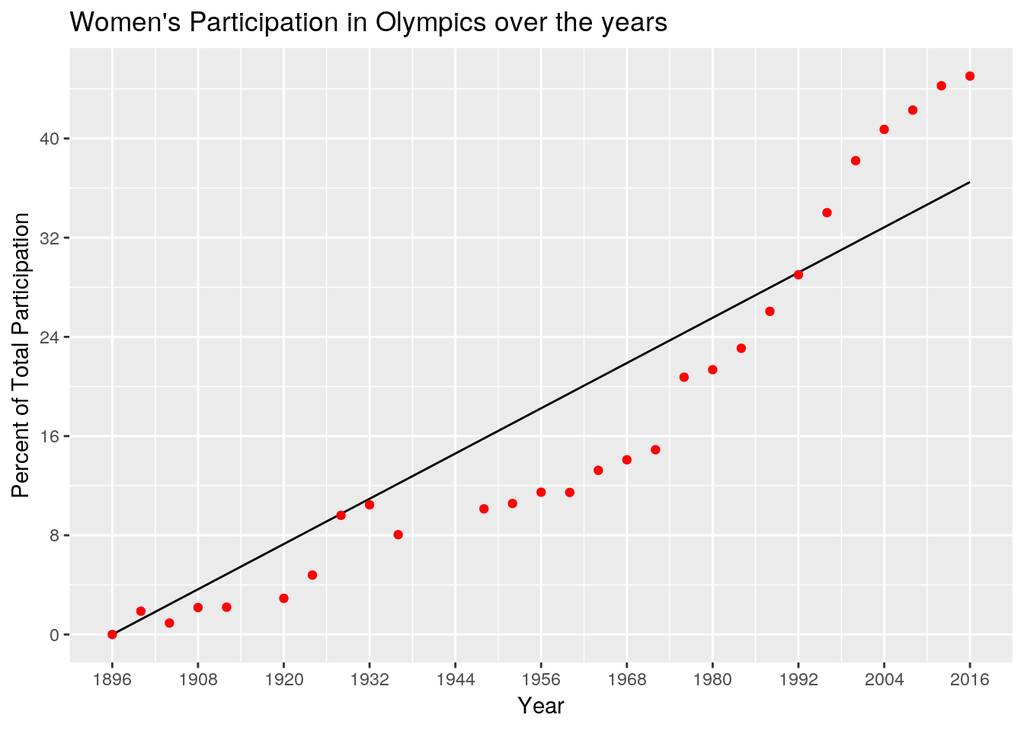

```
## Predicted 50% year: 2060
```

By the year 2060 Men and Women participation will be equal.

### Cold war’s effect on USA and Russia’s performance

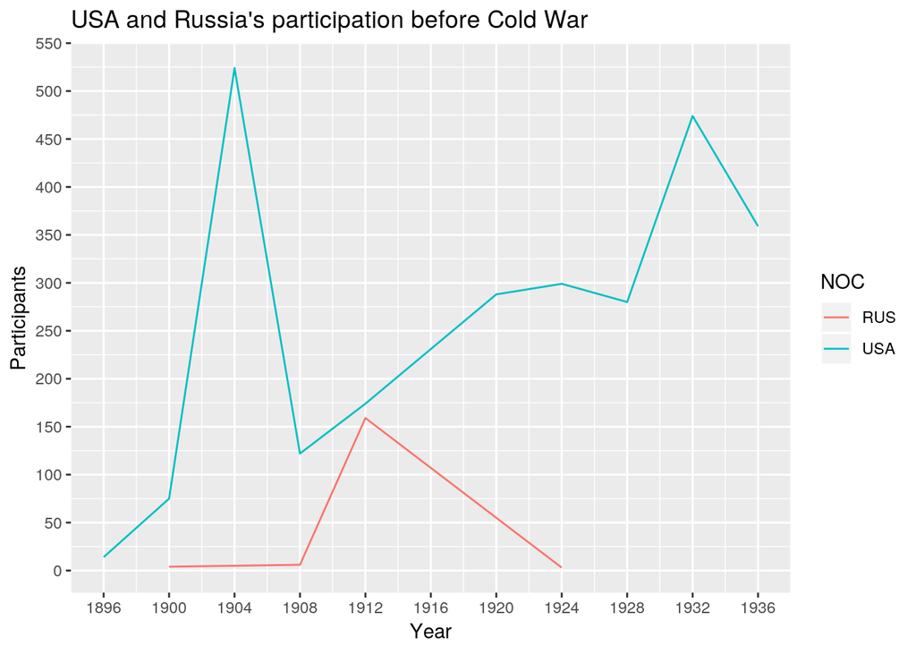

Select data that shows Russia and US performance before the cold war

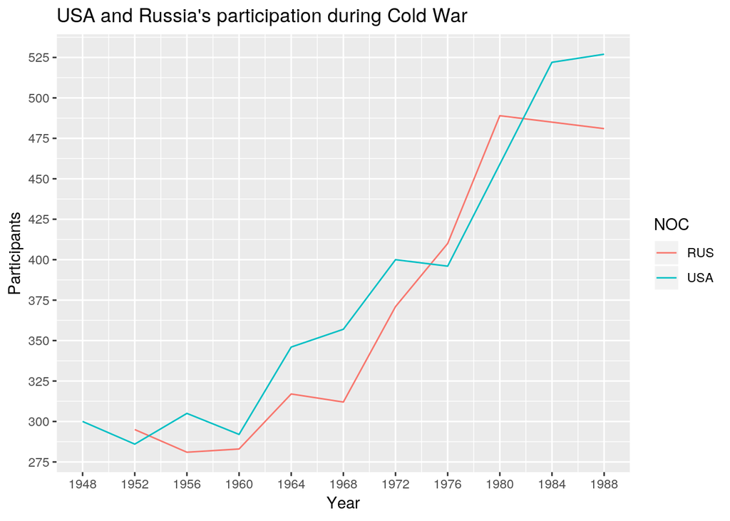

```
## Number of participants by Russia before the cold war 172
```

```
## Number of participants by USA before the cold war 2609
```

```
## Number of participants by Russia 3239
```

```
## Number of participants by USA 3731
```

Russia and US performance before the Cold War

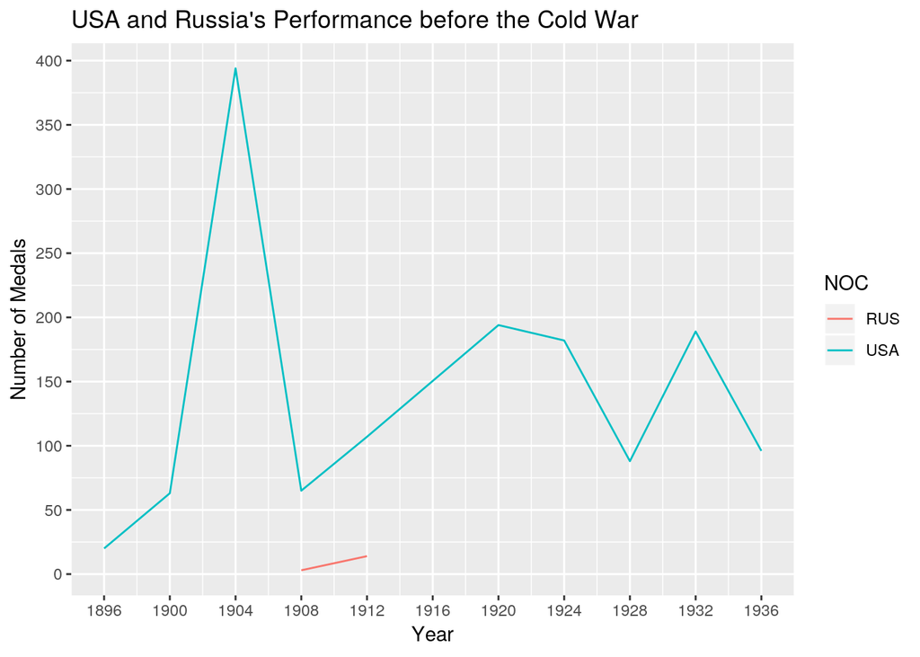

US outperformed Russia prior to the Cold War

Russia outperformed USA, in terms of medals won, in almost every Olympic during the Cold War.  
USA did not participate in the Olympics in 1980 and Russia did the same in 1948 and 1984.

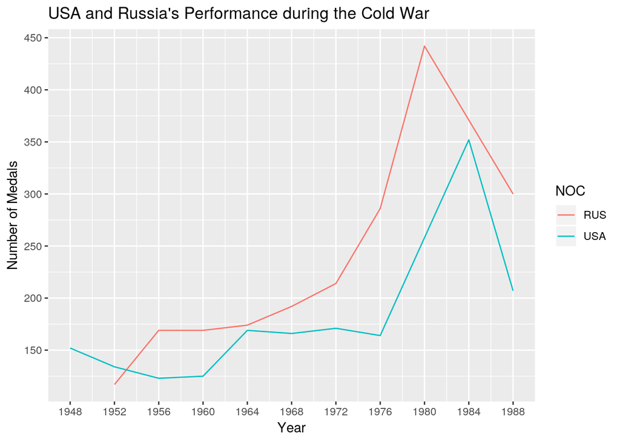

```
## Number of medals for Russia before the cold war: 17
```

```
## Number of medals for USA before the cold war: 1398
```

```
## Number of medals for Russia during the cold war: 2063
```

```
## Number of medals for USA during the cold war: 1763
```

Top 5 medal winners over all Olympics

```r
country_medals.total <- country_medals %>% group_by(NOC) %>% summarize(Medal_Count = sum(Medal_Count))
country_medals.total <- data.frame(country_medals.total[order(country_medals.total$Medal_Count, decreasing = T),])
print(country_medals.total[1:5,])
```

```
##   NOC Medal_Count
## 1 USA        4978
## 2 GER        3096
## 3 RUS        2968
## 4 GBR        1946
## 5 FRA        1563
```

Maximum medals earned by each sport, this tells us which sport is awarded the most medals by country. The USA is top in Swimming and Athletics

```r
country_medals.sport <- winners_only %>% group_by(NOC, Sport) %>% summarize(Medal_Count = n())

country_medals.sport <- country_medals.sport %>% group_by(Sport) %>% filter(Medal_Count == max(Medal_Count))
country_medals.sport <- country_medals.sport[order(country_medals.sport$Medal_Count, decreasing = T),]
print(country_medals.sport)
```

```
## # A tibble: 57 x 3
## # Groups:   Sport [52]
##    NOC   Sport         Medal_Count
##    <chr> <fct>               <int>
##  1 USA   Swimming             1077
##  2 USA   Athletics            1057
##  3 GER   Rowing                471
##  4 RUS   Gymnastics            371
##  5 ITA   Fencing               357
##  6 USA   Basketball            341
##  7 NED   Hockey                255
##  8 GER   Canoeing              229
##  9 RUS   Volleyball            211
## 10 GER   Equestrianism         205
## # ... with 47 more rows
```

```
## # A tibble: 52 x 2
##    Sport      Medal_count
##    <fct>            <int>
##  1 Athletics         3904
##  2 Swimming          3027
##  3 Rowing            2838
##  4 Gymnastics        2200
##  5 Fencing           1702
##  6 Football          1537
##  7 Hockey            1528
##  8 Wrestling         1284
##  9 Cycling           1242
## 10 Sailing           1232
## # ... with 42 more rows
```